# Tugas Mandiri Pengantar Model Linear 2

Farhan Abdillah Harahap (G1401211007)

## Packages

```r
#install.packages("ggplot2")
#install.packages("tsibble")
#install.packages("tseries")
#install.packages("MASS")
#install.packages("forecast")
#install.packages("TSA")
#install.packages("TTR")
#install.packages("aTSA")
#install.packages("graphics")
library(ggplot2)
library(tsibble)
library(tseries)
library(MASS)
library(forecast)
library(TSA)
library(TTR)
library(aTSA)
library(graphics)
```

## Data Bangkitan

### Pembangkitan Data

Data yang akan dibangkitkan adalah data dengan model MA(2) sebagai berikut.

```r
set.seed(99)
ma2 <- arima.sim(list(order = c(0,0,2), ma = c(0.55,0.65)), n = 175)
```

Data kemudian dibagi menjadi data latih dan data uji. Pembagian kali ini dilakukan dengan proporsi / perbandingan, yaitu 80:20.

```r
ma2 <- ma2[-c(1:25)]
ma2.train <- ma2[1:120]
ma2.test <- ma2[121:150]
```

### Eksplorasi Data

Sebelum masuk dalam tahap pemodelan, dilakukan eksplorasi data dengan plot deret waktu untuk melihat pola data.

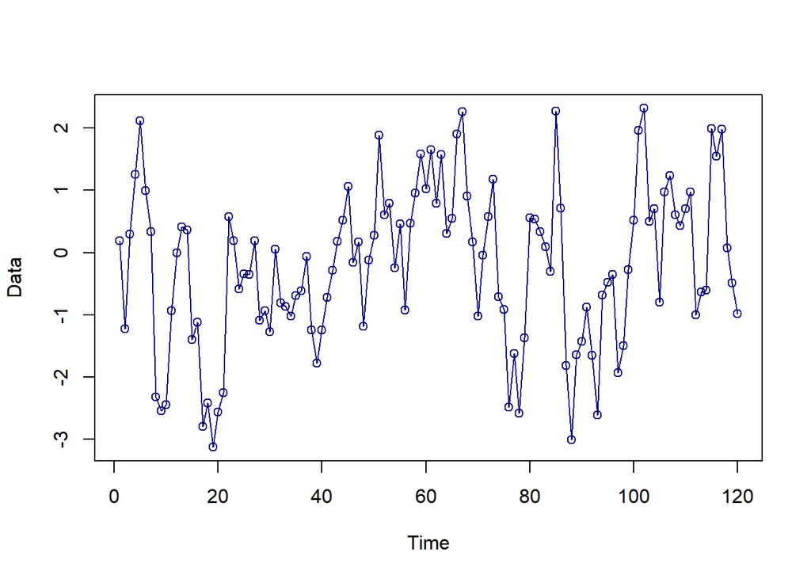

```r
#--PLOT TIME SERIES--#
plot(ma2.train,
     col = "navyblue",
     lwd = 1,
     type = "o",
     xlab = "Time",
     ylab = "Data")
```

Berdasarkan plot data deret waktu di atas, terlihat data cenderung stasioner dalam rataan dan ragam. Data stasioner dalam rataan karena menyebar/bergerak di sekitar nilai tengahnya (0) dan dikatakan stasioner dalam ragam karena memiliki lebar pita yang cenderung sama. Selain dengan plot data deret waktu, akan dilakukan pengecekan stasioneritas data dengan plot ACF dan uji ADF.

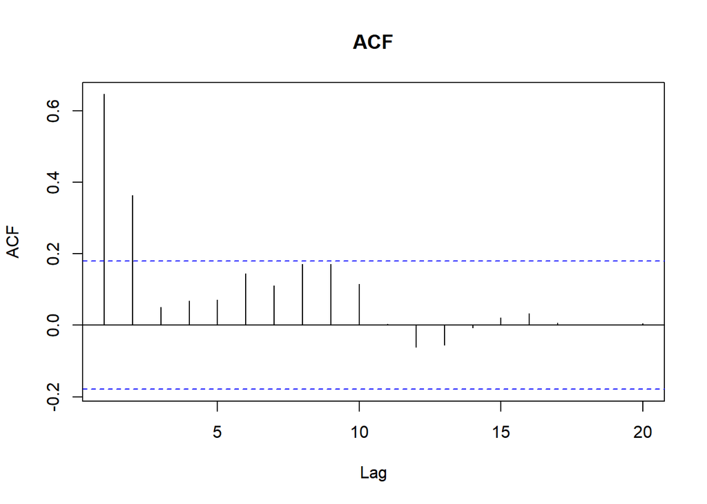

```r
#--CEK KESTASIONERAN---#
acf(ma2.train, main="ACF", lag.max=20)
```

Berdasarkan plot ACF di atas, dapat dilihat bahwa plot *cuts off* pada *lag* ke-2. Hal ini sesuai dengan proses pembangkitan model MA(2).

```r
adf.test(ma2.train)
```

```
## Augmented Dickey-Fuller Test
## alternative: stationary
##
## Type 1: no drift no trend
##      lag   ADF p.value
## [1,]   0 -4.91    0.01
## [2,]   1 -4.89    0.01
## [3,]   2 -5.65    0.01
## [4,]   3 -3.57    0.01
## [5,]   4 -3.43    0.01
## Type 2: with drift no trend
##      lag   ADF p.value
## [1,]   0 -4.99    0.01
## [2,]   1 -4.95    0.01
## [3,]   2 -5.78    0.01
## [4,]   3 -3.69    0.01
## [5,]   4 -3.59    0.01
## Type 3: with drift and trend
##      lag   ADF p.value
## [1,]   0 -5.10  0.0100
## [2,]   1 -5.04  0.0100
## [3,]   2 -6.02  0.0100
## [4,]   3 -3.99  0.0123
## [5,]   4 -3.96  0.0138
## ----
## Note: in fact, p.value = 0.01 means p.value <= 0.01
```

```r
#stasioner
```

$H_0$ : Data tidak stasioner dalam rataan

$H_1$ : Data stasioner dalam rataan

### Spesifikasi Model

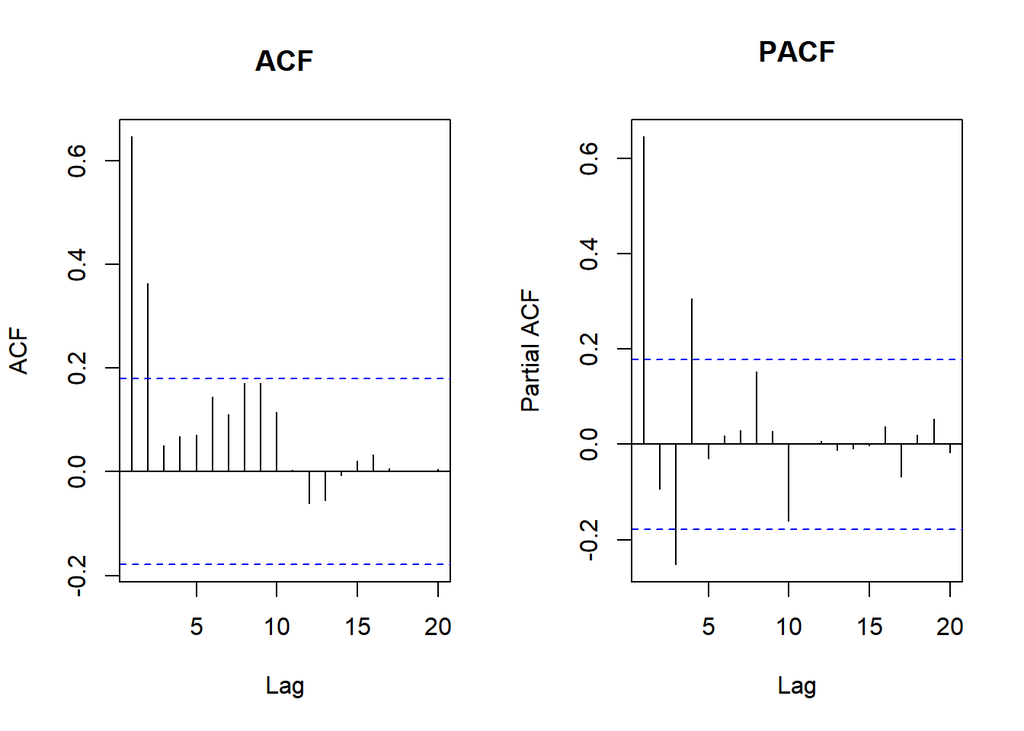

```r
#---SPESIFIKASI MODEL---#
par(mfrow = c(1,2))
acf(ma2.train, main="ACF", lag.max=20) #ARIMA(0,0,2)
pacf(ma2.train, main="PACF", lag.max=20) #ARIMA(1,0,0)
```

```r
par(mfrow = c(1,1))
```

```r
eacf(ma2.train)
```

```
## AR/MA
##   0 1 2 3 4 5 6 7 8 9 10 11 12 13
## 0 x x o o o o o o o o o  o  o  o
## 1 o x x o o o o o o o o  o  o  o
## 2 x x x o o o o o o o o  o  o  o
## 3 x x x o o o o o o o o  o  o  o
## 4 o o o x o o o o o o o  o  o  o
## 5 x o o x o o o o o o o  o  o  o
## 6 x o o o o o o o x o o  o  o  o
## 7 o o o o o x o o o o o  o  o  o
```

```r
#ARIMA(0,0,2) #ARIMA(1,0,3) #ARIMA(2,0,3) #ARIMA(3,0,3)
#Terdapat 5 model tentatif
```

Menggunakan plot EACF, dapat diambil beberapa model dengan melihat ujung segitiga yang terbentuk, antara lain ARIMA(0,0,2), ARIMA(1,0,3), ARIMA(2,0,3), dan ARIMA(3,0,3).